# 02: Benchmark Models

Herman Yu

# Introduction

Forecasting might seem like a highly complex problem, but simple methods can actually produce rather effective forecasts. This section will discuss a few simple forecasting methods that can be used to establish baseline models; more sophisticated models should be compared against these established benchmarks. If a complex model only has marginally better performance than a simple method, we generally will prefer the simpler method.

To ground our discussion, we will use the Australian brick production data found in the `aus_production` data set.

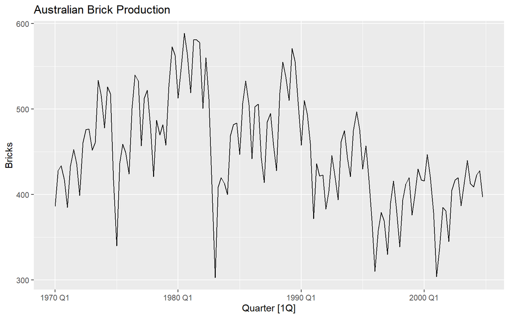

```r
options(scipen=999)
library(fpp3)
library(DT)

bricks <- aus_production %>%
  select(Bricks) %>%
  filter_index("1970 Q1" ~ "2004 Q4")

bricks %>%
  autoplot(Bricks) +
  labs(title = "Australian Brick Production")
```

We will split our data set into a training set and testing set:

```r
bricks_train <- bricks %>%
  filter_index(
    "1970 Q1" ~ "1999 Q4"
  )

bricks_test <- bricks %>%
  filter_index(
    "2000 Q1" ~ "2004 Q4"
  )
```

# Overall Mean Model

## Model Specification

The **mean model** hypothesizes that the true data generation process is an i.i.d. random sample. Formally, we hypothesize that:

$$Y_t = \mu + \epsilon_t$$

where the $\epsilon_t$ are i.i.d. with $\epsilon_t \sim N(0, \sigma)$. In particular, this model implies that the $Y_t$ are also i.i.d. with $Y_t \sim N(\mu, \sigma)$.

## Model Fitting

The deterministic piece is just the population mean $\mu = E[Y_t \,\,|\,\, t] = E[Y]$. We can estimate the population mean $\mu$ using the sample average:

$$\hat{y}_t = \hat{\mu} = \frac{1}{T}\sum_{t=1}^Ty_i$$

and the resulting fitted model $\hat{f}(t)$ just predicts the sample mean at each time $t$:

$$\hat{f}(t) = \frac{1}{T}\sum_{t=1}^Ty_i$$

Note that the constant function $\hat{f}(t)$ is equivalent to an OLS regression estimating a *constant of best fit*; the sample mean is the constant which minimizes the squared-error of a given sample.

$$\hat{f}(t) = \hat{\mu} = \min_{c} \sum_{t=1}^T(y_i - c)^2$$

```r
# fit a mean model for Australian brick production;
# the MEAN() function from fable will specify a mean model
bricks_mean_model <- model(
  .data = bricks_train,
  `Mean Model` = MEAN(Bricks)
)

bricks_mean_model
```

```
## # A mable: 1 x 1
##   `Mean Model`
##        <model>
## 1       <MEAN>
```

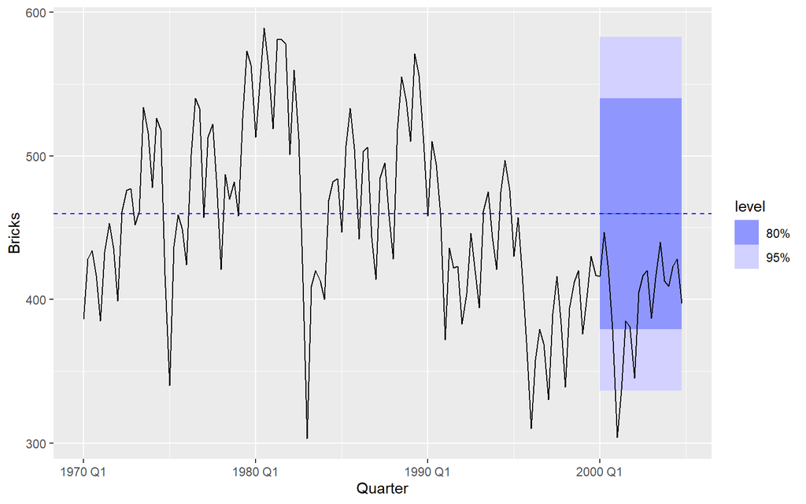

```r
sample_mean <- mean(bricks_train$Bricks)

bricks_mean_model %>%
  forecast(h = 20) %>%
  autoplot(bricks) +
  geom_hline(yintercept = sample_mean, linetype = "dashed", color = "blue")
```

## Model Evaluation

### Out-Of-Sample Error

The various generalization errors of the mean model fitted are:

```r
mean_model_test_forecast <- forecast(
  bricks_mean_model,
  h = 20 # 2000 Q1 to 2004 Q4
)

accuracy(
  mean_model_test_forecast,
  bricks_test
) %>%
  mutate(
    across(where(is.numeric), ~round(., 3))
  ) %>%
  datatable()
```

|  | .model | .type | ME | RMSE | MAE | MPE | MAPE | MASE | RMSSE | ACF1 |
| --- | --- | --- | --- | --- | --- | --- | --- | --- | --- | --- |
| 1 | Mean Model | Test | -61.167 | 70.428 | 61.167 | -16.358 | 16.358 |  |  | 0.544 |

On average, the mean model is off by 61 units, which corresponds to an average percentage error of 16.3% relative to the actual value.

### Residual Diagnostics

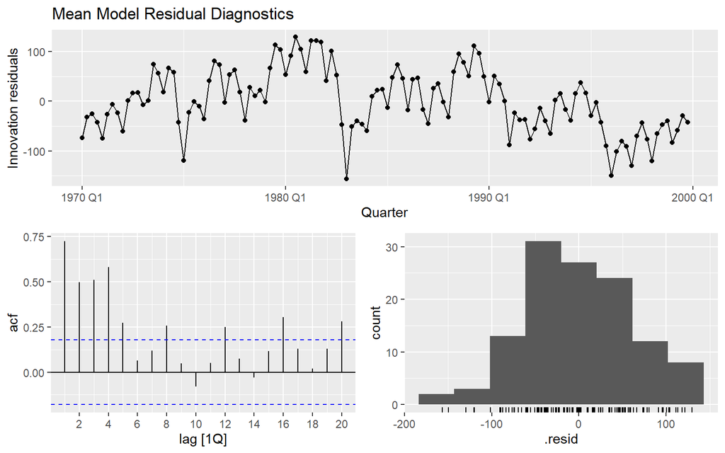

```r
bricks_mean_model %>%
  gg_tsresiduals() +
  labs(title = "Mean Model Residual Diagnostics")
```

The residual plot exhibits autocorrelation and seasonal patterns, indicating the model is biased and underfit. This is not too surprising considering the simplicity of the model.

# Naive Model

The autocorrelation exhibited by the residuals of the mean model indicate that Australian brick production is a continuous function of time: observations close together in time will have similar values. Let us return to the beginning and perform some EDA:

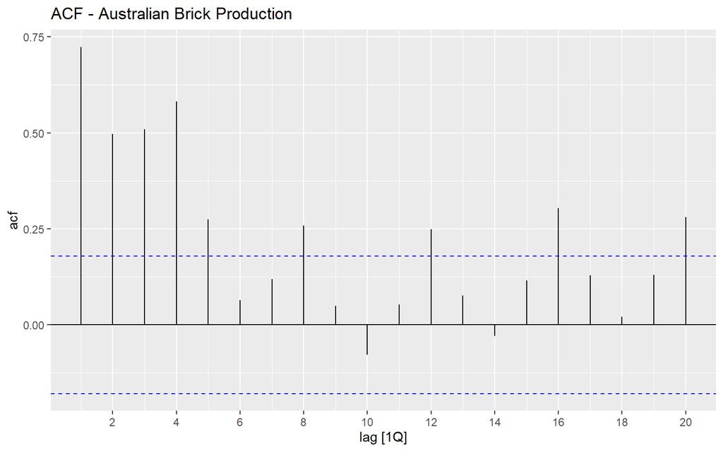

```r
bricks_train %>%
  ACF(Bricks) %>%
  autoplot() +
  labs(title = "ACF - Australian Brick Production")
```

The ACF plot reveals that Australian brick production exhibits strong autocorrelations with lags 1, 2, 3, 4, and 5. Consequently, this implies that $Y_t$ should be correlated with at least $Y_{t-1}$.

## Model Specification

The **naive model** aka **random walk model** hypothesizes that the data generation process is recursive of the form:

$$Y_0 = y_0\\
Y_t = Y_{t-1} + \epsilon_t$$

where the $\epsilon_t$ are i.i.d. with $e_t \sim N(0, \sigma)$. In particular, we can “unpack” the recursive definition to get:

$$\begin{align*}
Y_t &= Y_{t-1} + \epsilon_t \\
&= Y_{t-2} + \epsilon_{t-1} + \epsilon_t\\
&= \ldots \\
&= Y_1 + \epsilon_2 + \ldots + \epsilon_t\\
&= y_0 + \epsilon_1 + \epsilon_2 + \ldots + \epsilon_t\\
\end{align*}$$

Thus, the naive model says that the data is generated by starting at some point $y_0$, then taking a random step $\epsilon$ to reach the next value. For this reason, this process is also called a **random walk**.

## Model Fitting

The point estimate for $y_t$ based on the naive model specification is:

$$E[Y_t \,\,|\,\,t] = E[Y_{t-1} + \epsilon_t \,\,|\,\, t]$$
Note here the expected value is conditioned on $t$, so the point estimate *depends* on the information we have available at time $t$. In particular, if $t \leq T + 1$, then the time point $t-1$ is within the observed sample and $Y_{t-1}$ is no longer random but takes on the definite value $y_{t-1}$:

$$\begin{align*}
E[Y_t\,\,|\,\,T] &= E[Y_{t-1} + \epsilon_t \,\,|\,\, T]\\
&= E[Y_{t-1}\,\,|\,\,T] + E[\epsilon_t \,\,|\,\, T]\\
&= y_{t-1} + E[\epsilon_t \,\,|\,\,T]\\
&= y_{t-1}
\end{align*}$$

On the other hand, if $t > T + 1$, then we no longer have information on $y_{t-1}$, in this case $Y_t$ must still be treated as a random variable:

$$\begin{align*}
E[Y_t\,\,|\,\,t] &= E[Y_{t-1} + \epsilon_t \,\,|\,\, T]\\
&= E[Y_{t-1}\,\,|\,\,T] + E[\epsilon_t \,\,|\,\, T]\\
&= E[Y_{t-2}\,\,|\,\,T] + E[\epsilon_{t-1} \,\,|\,\, T] +
E[\epsilon_t \,\,|\,\, T]\\
&= \ldots \\
&= E[Y_t\,\,|\,\,T] + E[\epsilon_{T+1} \,\,|\,\, T] + \ldots +
E[\epsilon_t \,\,|\,\, T]\\
&= y_T + E[\epsilon_{T+1} \,\,|\,\, T] + \ldots + E[\epsilon_t
\,\,|\,\, T]\\
&= y_T
\end{align*}$$

Therefore, the naive model will fit a function of the form:

$$\hat{f}(t) := \hat{y}_t = \begin{cases}
y_{t-1} & t \leq T + 1\\
y_T & t > T + 1
\end{cases}$$

```r
# fit a naive model (aka random walk);
# the NAIVE() function from fable will specify a naive model
bricks_naive_model <- model(
  .data = bricks_train,
  `Naive Model` = NAIVE(Bricks)
)

bricks_naive_model
```

```
## # A mable: 1 x 1
##   `Naive Model`
##         <model>
## 1       <NAIVE>
```

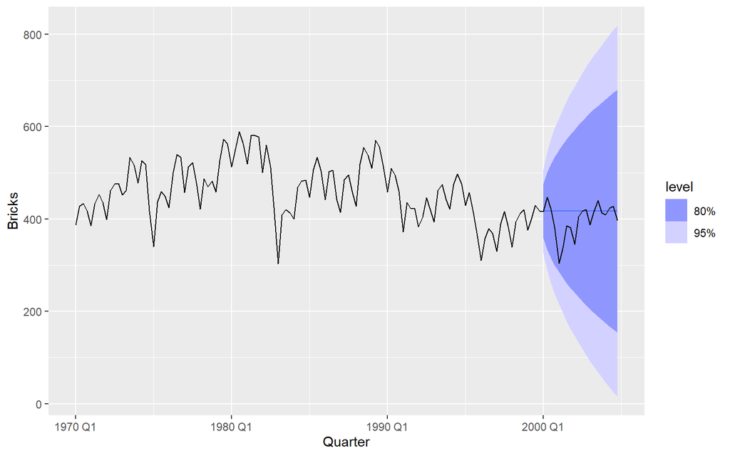

```r
bricks_naive_model %>%
  forecast(
    h = 20
  ) %>%
  autoplot(
    bricks
  )
```

## Model Evaluation

### Out-Of-Sample Error

The various generalization errors for the naive model are:

```r
bricks_naive_model %>%
  forecast(
    h = 20
  ) %>%
  accuracy(
    bricks_test
  ) %>%
  mutate(
    across(where(is.numeric), ~round(., 3))
  ) %>%
  datatable()
```

|  | .model | .type | ME | RMSE | MAE | MPE | MAPE | MASE | RMSSE | ACF1 |
| --- | --- | --- | --- | --- | --- | --- | --- | --- | --- | --- |
| 1 | Naive Model | Test | -18.55 | 39.533 | 26.25 | -5.569 | 7.328 |  |  | 0.544 |

This model generalizes much better on out-of-sample data compared to the mean model. The MAE is 26 units with corresponds to an average percentage error of only 7% relative to the actual values.

### Residual Diagnostics

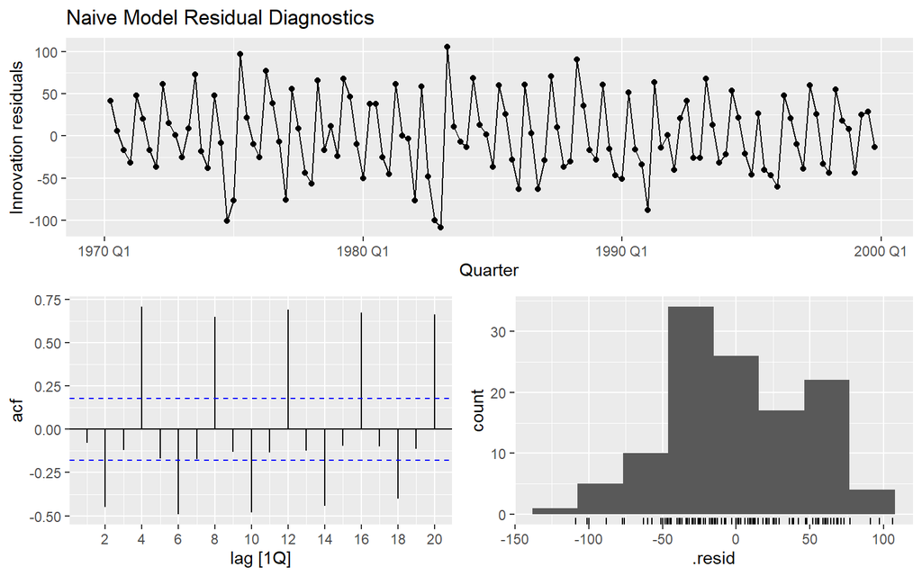

```r
bricks_naive_model %>%
  gg_tsresiduals() +
  labs(title = "Naive Model Residual Diagnostics")
```

The autocorrelation we saw from the mean model seems to have dissipated when moving to the naive model; this indicates the naive model does a good job at extracting the predictable information. However, we see something interesting: periodic spikes of autocorrelation at lags 4, 8, 12, 16, etc. This indicates that the residuals exhibit a seasonal pattern with periodicity of 4 (i.e. there is a pattern based on the quarter of the year).

# Seasonal Naive Model

The naive model did a good job at modeling the autocorrelation, but we a seasonal pattern exists within the residual plots. This indicates we should once again return to our data and perform some EDA:

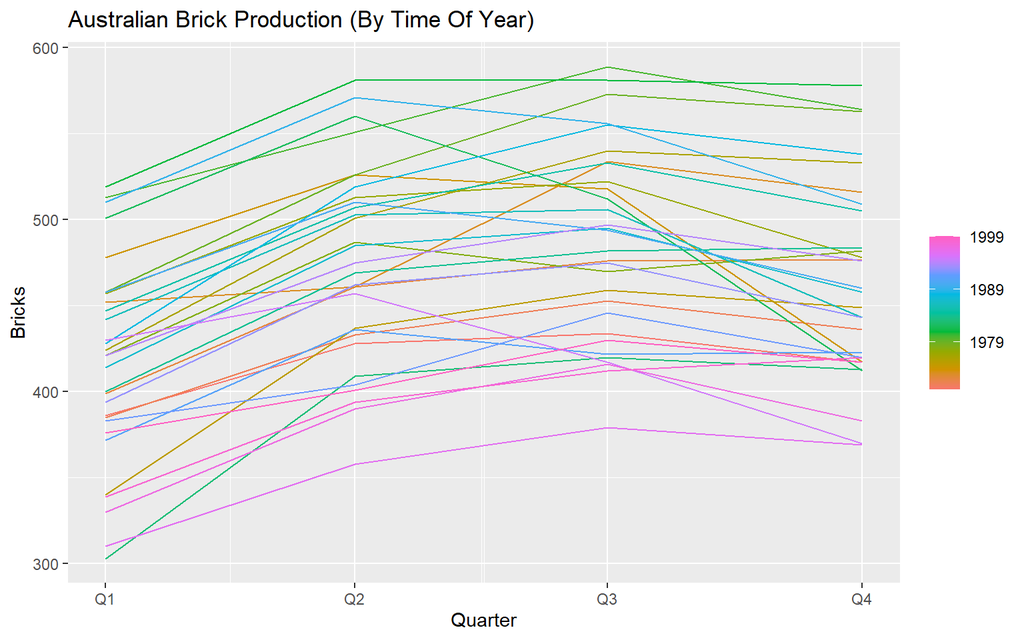

```r
bricks_train %>%
  gg_season(Bricks, period = "year") +
  labs(title = "Australian Brick Production (By Time Of Year)")
```

The seasonal plot of Australian brick production shows that the data does have a strong seasonal pattern: brick production starts off lower in Q1, rises throughout Q2 and Q3, then flattens in Q4.

## Model Specification

The **seasonal naive model** hypothesizes that the data generation process follows a periodic recursive form:

$$\begin{align*}
Y_0 &= y_0\\\
&\vdots\\
Y_{p-1} &= y_{p-1}\\
Y_t &= Y_{t-p} + \epsilon_t
\end{align*}$$

where $p$ is the periodicity of the seaosnality. This is equivalent to saying that the data will follow a naive model after controlling for the seasonal period.

## Modeling Fitting

Since the seasonal naive model reduces to a naive model after grouping by seasonal period, the logic from the previous section can be used derive the point estimates for the seasonal naive model.

$$\hat{f}(t) = \hat{y}_t := \begin{cases}
y_{t-p} & t \leq T+p\\
y_{T- (t \text{ mod p})} & t > T+P
\end{cases}$$

In other words, the seasonal naive model just predicts the value from the previous seasonal period.

```r
# fit a seasonal naive model;
# the SNAIVE() function from fable specifies
# a seasonal naive model
bricks_seasonal_naive_model <- model(
  .data = bricks_train,
  `Seasonal Naive Model` = SNAIVE(Bricks)
)

bricks_seasonal_naive_model
```

```
## # A mable: 1 x 1
##   `Seasonal Naive Model`
##                  <model>
## 1               <SNAIVE>
```

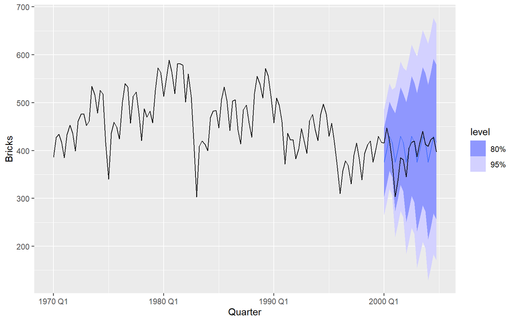

```r
bricks_seasonal_naive_model %>%
  forecast(
    h = 20
  ) %>%
  autoplot(
    bricks
  )
```

## Model Evaluation

### Out-Of-Sample Error

The various generalization errors for the seasonal naive model are:

```r
bricks_seasonal_naive_model %>%
  forecast(
    h = 20
  ) %>%
  accuracy(
    bricks_test
  ) %>%
  mutate(
    across(where(is.numeric), ~round(., 3))
  ) %>%
  datatable()
```

|  | .model | .type | ME | RMSE | MAE | MPE | MAPE | MASE | RMSSE | ACF1 |
| --- | --- | --- | --- | --- | --- | --- | --- | --- | --- | --- |
| 1 | Seasonal Naive Model | Test | -7.55 | 32.716 | 25.85 | -2.559 | 6.896 |  |  | 0.693 |

The generalization errors for the seasonal naive model are marginally better than the naive model.

### Residual Diagnostics

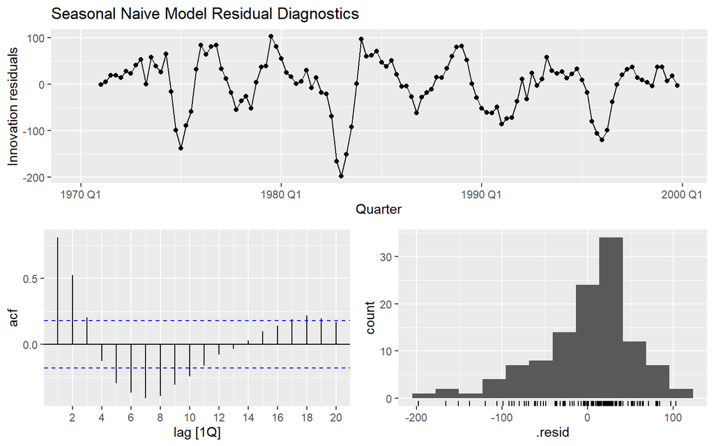

```r
bricks_seasonal_naive_model %>%
  gg_tsresiduals() +
  labs(title = "Seasonal Naive Model Residual Diagnostics")
```

The seasonal naive model (unsurprisingly) captured most of the regular cyclic behavior, but does not seem to capture as much of the autocorrelation as the naive model.

# Combination Models

For the naive and seasonal naive model, we observed that:

1. The naive model does a good job at capturing the autocorrelation but not the seasonality.
2. The seasonal naive model does a good job at capturing seasonality, but still leaves a lot of autocorrelation.

It would be great if we could somehow combine both the models to capture the autocorrelation *and* the seasonality at the same time.

## Model Specification

We hypothesize that the data generation process is a combination of the naive and seasonal naive model:

$$\begin{align*}
Y_0 &= y_0\\\
&\vdots\\
Y_{p-1} &= y_{p-1}\\
Y_t &= \frac{Y_{t-1} + Y_{t-p}}{2} + \epsilon_t
\end{align*}$$

More generally, a **combination model** or **Delphi model** is an average of multiple different forecasting models. This is analogous to an **ensemble model** in machine learning.

## Model Fitting

The combination model amounts to taking an average of the point estimates from the naive and seasonal naive models:

$$\hat{f}(t) = \hat{y}_t := \begin{cases}
\frac{y_{t-1} + y_{t-p}}{2} & t \leq T+p\\
\frac{y_T + y_{T- (t \text{ mod p})}}{2} & t > T+P
\end{cases}$$

```r
# fit a combination of
# the naive and seasonal naive models;
# this can be done by specifying the arithmetic
# within the model() function
bricks_combo_model <- model(
  .data = bricks_train,
  `Combo Model` = ( NAIVE(Bricks) + SNAIVE(Bricks) )/2
)

bricks_combo_model
```

```
## # A mable: 1 x 1
##   `Combo Model`
##         <model>
## 1 <COMBINATION>
```

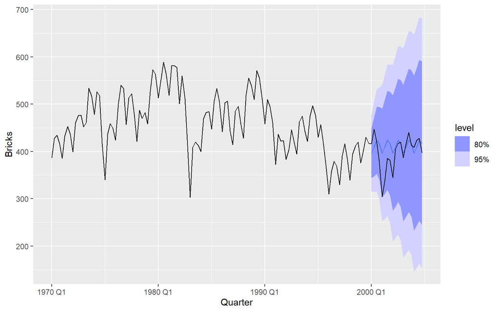

```r
bricks_combo_model %>%
  forecast(
    h = 20
  ) %>%
  autoplot(
    bricks
  )
```

## Model Evaluation

### Out-Of-Sample Error

The various generalization errors of the model is given by:

```r
bricks_combo_model %>%
  forecast(
    h = 20
  ) %>%
  accuracy(
    bricks_test
  ) %>%
  mutate(
    across(where(is.numeric), ~round(., 3))
  ) %>%
  datatable()
```

|  | .model | .type | ME | RMSE | MAE | MPE | MAPE | MASE | RMSSE | ACF1 |
| --- | --- | --- | --- | --- | --- | --- | --- | --- | --- | --- |
| 1 | Combo Model | Test | -13.05 | 34.423 | 24.45 | -4.064 | 6.716 |  |  | 0.671 |

### Residual Diagnostics

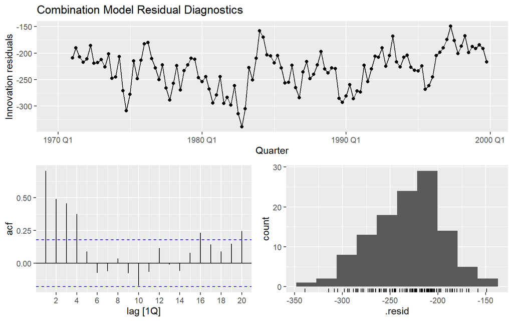

```r
bricks_combo_model %>%
  gg_tsresiduals() +
  labs(title = "Combination Model Residual Diagnostics")
```

There is still autocorrelation in the residuals, but it has been reduced by a non-trivial amount.

# Drift Model

The forecast for the naive and seasonal naive models are semi-constant across time. Consequently, the forecasts from these models will become worse if the data is trending in a certain direction. For example, consider the Australian brick prodution data from 1980 to 1999:

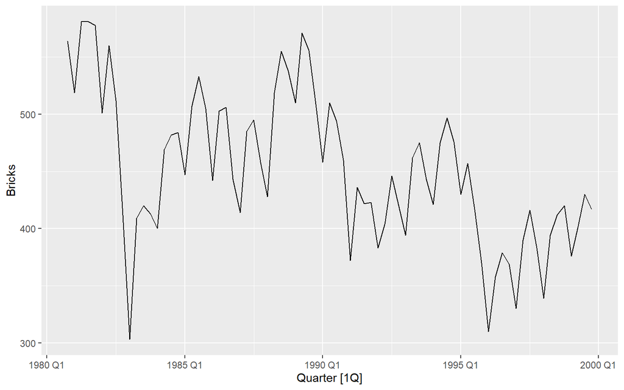

```r
bricks_train %>%
  filter_index(
    "1980 Q4" ~ "1999 Q4"
  ) %>%
  autoplot(Bricks)
```

We see a consistent downward trend starting from 1980 through the end of 1999.

## Model Specification

A **drift** or **random walk with drift** model is a model of the following form:

$$\begin{align*}
Y_0 &= y_0 \\
Y_t &= a + Y_{t-1} + \epsilon_t
\end{align*}$$

As with the random walk model, we can “unpack” the recursive definition to get:

$$\begin{align*}
Y_t &= a + Y_{t-1} + \epsilon_t \\
&= 2a + Y_{t-2} + \epsilon_{t-1} + \epsilon_t\\
&= \ldots \\
&= (t-1)a + Y_1 + \epsilon_2 + \ldots + \epsilon_t\\
&= ta + y_0 + \epsilon_1 + \epsilon_2 + \ldots + \epsilon_t\\
\end{align*}$$

This is equivalent to including a linear trend $t\cdot a$ in the random walk model.

## Model Fitting

```r
# fit a random walk with drift model;
# the RW() function will specify a random walk model
# and the special drift() can be used to indicate a drift term
# in the model formula
bricks_drift_model <- model(
  .data = bricks_train %>%
    filter_index(
      "1980 Q4" ~ "1999 Q4"
    )
  ,
  `Random Walk With Drift` = RW( Bricks ~ drift() )
)

bricks_drift_model
```

```
## # A mable: 1 x 1
##   `Random Walk With Drift`
##                    <model>
## 1            <RW w/ drift>
```

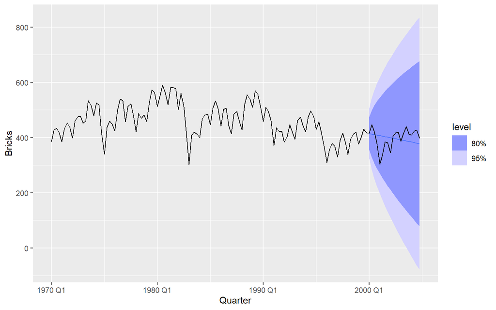

```r
bricks_drift_model %>%
  forecast(
    h = 20
  ) %>%
  autoplot(
    bricks
  )
```

## Model Evaluation

### Out-Of-Sample Error

```r
bricks_drift_model %>%
  forecast(h = 20) %>%
  accuracy(
    bricks_test
  ) %>%
  mutate(
    across(where(is.numeric), ~round(., 3))
  ) %>%
  datatable()
```

|  | .model | .type | ME | RMSE | MAE | MPE | MAPE | MASE | RMSSE | ACF1 |
| --- | --- | --- | --- | --- | --- | --- | --- | --- | --- | --- |
| 1 | Random Walk With Drift | Test | 1.759 | 39.654 | 31.801 | -0.513 | 8.44 |  |  | 0.646 |

### Residual Diagnostics

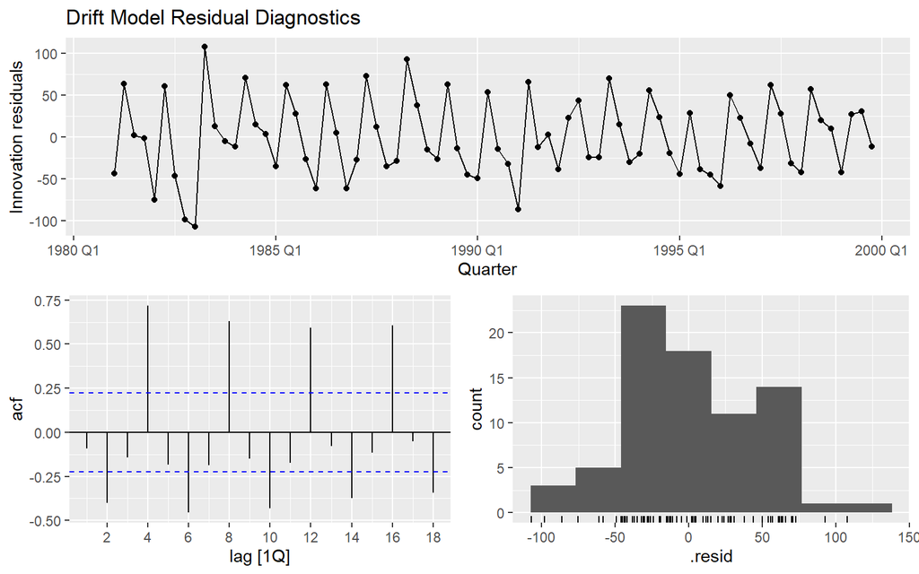

```r
bricks_drift_model %>%
  gg_tsresiduals() +
  labs(title = "Drift Model Residual Diagnostics")
```

# Time Series Decomposition Model

## Model Specification

We had previously discussed the concept of a time series decomposition by modeling the data generating process as:

$$Y_t = Tr(t) + S(t) + \epsilon_t$$

where $S(t)$ is a periodic function with period $p$.

## Model Fitting

When we originally discussed the time series decomposition model, it was primarily used as a “look back” model because the estimated trend component $Tr(t)$ was estimated using values at future times $y_{t+1},y_{t+2},\ldots, y_{t+k}$. This makes the original estimation procedure unsuitable for forecasting. However, the resulting seasonality component *does not depend* on future data, so the estimated $\hat{S}(t)$ *can be used* for forecasting. Therefore, to fit a time series decomposition model for forecasting, we do the following:

1. Estimate the “historic” trend $\hat{Tr}_{hist}(t)$ and the seasonality component $\hat{S}(t)$ using either a classical decomposition or STL.
2. De-season the time series by computing $\tilde{y}_t = y_t - \hat{S}(t)$.
3. Re-estimate the trend component $\hat{Tr}(t)$ by fitting a forecasting model on the de-seasoned series $\tilde{y}_t$

```r
# Estimate the historic trend to extract the seasonal component.
# The de-seasoned time series is stored in the season_adjust column.
bricks_decomp_historic <- model(
  .data = bricks_train,
  historic_decomp = STL(
    Bricks ~ trend(window = 8),
    robust = TRUE
  )
) %>%
  components() %>%
  select(-.model)

bricks_decomp_historic %>%
  head(10) %>%
  mutate(
    across(where(is.numeric), ~round(., 3))
  ) %>%
  datatable()
```

|  | Quarter | Bricks | trend | season_year | remainder | season_adjust |
| --- | --- | --- | --- | --- | --- | --- |
| 1 | 0 | 386 | 416.435 | -36.576 | 6.141 | 422.576 |
| 2 | 90 | 428 | 416.998 | 11.478 | -0.477 | 416.522 |
| 3 | 181 | 434 | 417.829 | 24.348 | -8.176 | 409.652 |
| 4 | 273 | 417 | 418.738 | 0.852 | -2.59 | 416.148 |
| 5 | 365 | 385 | 420.155 | -36.88 | 1.726 | 421.88 |
| 6 | 455 | 433 | 424.314 | 11.546 | -2.859 | 421.454 |
| 7 | 546 | 453 | 428.921 | 24.728 | -0.649 | 428.272 |
| 8 | 638 | 436 | 434.183 | 0.709 | 1.109 | 435.291 |
| 9 | 730 | 399 | 440.872 | -37.172 | -4.701 | 436.172 |
| 10 | 821 | 461 | 449.934 | 11.642 | -0.576 | 449.358 |

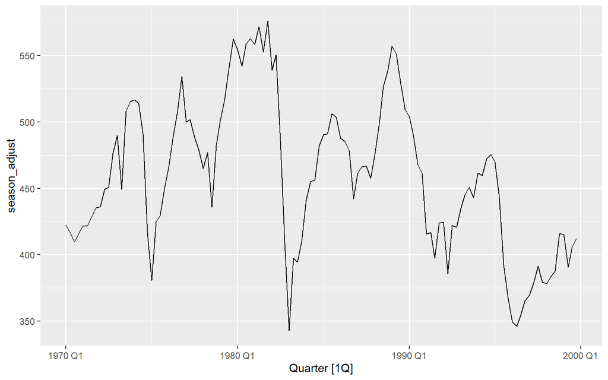

```r
bricks_decomp_historic %>%
  autoplot(season_adjust) +
  labs("De-Seasoned Australian Brick Production")
```

```r
# Estimate the "true" trend on the de-seasoned series.
bricks_decomp_trend_model <- model(
  .data = bricks_decomp_historic
  ,
  `Naive Trend` = NAIVE(season_adjust)
)

bricks_decomp_trend_model
```

```
## # A mable: 1 x 1
##   `Naive Trend`
##         <model>
## 1       <NAIVE>
```

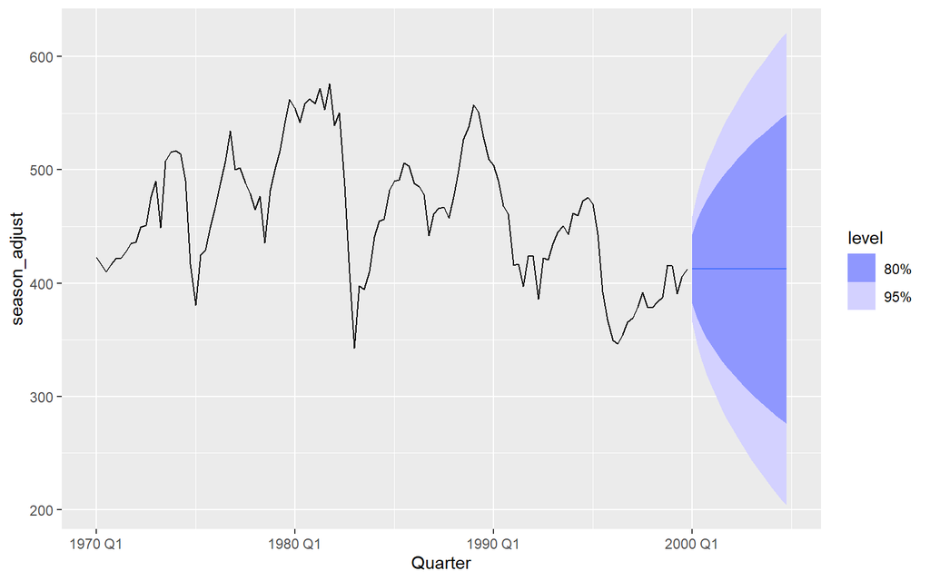

```r
bricks_decomp_trend_model %>%
  forecast(
    h = 20
  ) %>%
  autoplot(
    bricks_decomp_historic
  )
```

To recover a forecast for the actual $y_t$, we simply add the estimated $\hat{Tr}(t)$ from the naive model with the estimated $\hat{S}(t)$ from the STL model. This entire process is quite tedious to do manually, but thankfully `fable` has a built-in capability for performing all of these steps at once.

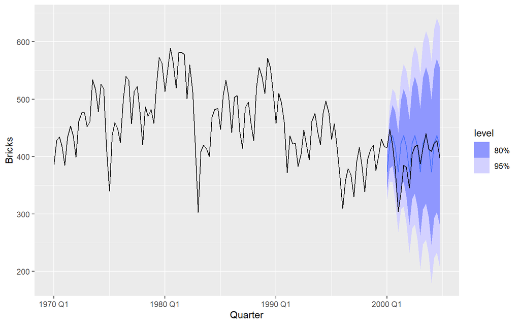

```r
bricks_decomp_model <- model(
  .data = bricks_train,
  `TS Decomp Model` = decomposition_model(
    STL( Bricks ~ trend(window = 8), robust = TRUE),
    NAIVE(season_adjust)
  )
)

bricks_decomp_model %>%
  forecast(h=20) %>%
  autoplot(bricks)
```

## Model Evaluation

### Out-Of-Sample Error

```r
bricks_decomp_model %>%
  forecast(h=20) %>%
  accuracy(bricks_test)
```

```
## # A tibble: 1 × 10
##   .model          .type    ME  RMSE   MAE   MPE  MAPE  MASE RMSSE  ACF1
##   <chr>           <chr> <dbl> <dbl> <dbl> <dbl> <dbl> <dbl> <dbl> <dbl>
## 1 TS Decomp Model Test  -14.0  34.5  26.3 -4.14  7.08   NaN   NaN 0.676
```

### Residual Diagnostics

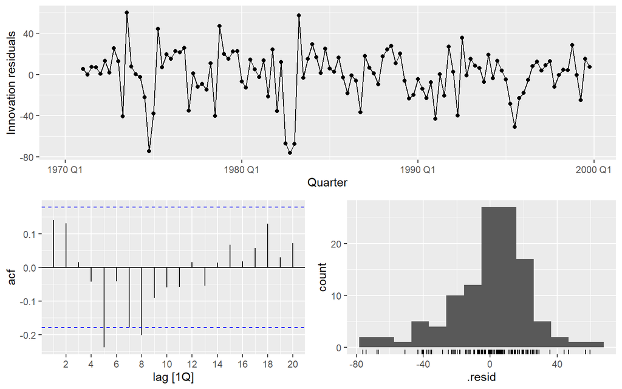

```r
bricks_decomp_model %>%
  gg_tsresiduals()
```

## The time series decomposition model seems to accurately capture most of the autocorrelation and seasonality.